# Lecture 6: Wishart Distribution

Zhaoxia Yu

Professor, Department of Statistics

2026-05-31

```r
knitr::opts_chunk$set(echo = TRUE)
library(tidyr) #the pipe (%>%) tool is extremely useful
library(MASS)
library(corrplot)#for visualizing the corr matrix of the iris data
library(car)
```

# The Big Picture

## Univariate vs Multivariate

- **Review**: A random sample, denoted by $X_1, \cdots, X_n$, from a (univariate) normal distribution $N(\mu, \sigma^2)$
  - What are the distributions of $\bar X, s^2$? What useful statistics can be constructed?
- **New material**: A random sample, denoted by $\mathbf X_1, \cdots, \mathbf X_n$, from a multivariate normal distribution $N(\boldsymbol \mu, \boldsymbol \Sigma)$
  - What are the distributions of $\bar{\mathbf X}, \mathbf S$? What useful statistics can be constructed?

## Univariate

- A random sample, denoted by $X_1, \cdots, X_n$, from a normal distribution $N(\mu, \sigma^2)$
- Let $\mathbf X_{n\times 1}=(X_1, \cdots, X_n)^T$. It is random vector with a MVN, i.e.,
  $$\mathbf X_{n\times 1}=(X_1, \cdots, X_n)^T \sim \mathbf N(\mu\mathbf 1, \sigma^2\mathbf I)$$
1. $\bar X \sim N(\mu, \sigma^2/n)$
2. $\frac{(n-1)s^2}{\sigma^2} \sim \chi_{n-1}^2$
3. Independence between $\bar X$ and $s^2$.
4. T-statistic:

$$\frac{\frac{\bar X-\mu}{\sqrt{\sigma^2/n}}}{\sqrt{\frac{(n-1)s^2/\sigma^2}{n-1}}}=\frac{\sqrt{n}(\bar X-\mu)}{s}\sim t_{n-1}.$$

## Multivariate

- A random sample $\mathbf X_1, \cdots, \mathbf X_n$ from a MVN $\mathbf N(\boldsymbol \mu, \boldsymbol \Sigma)$.
- Let
  $$\mathbf X_{n\times p}=\begin{pmatrix}
  \mathbf X_1^T \\ \vdots \\\mathbf X_n^T
  \end{pmatrix}$$
  $\mathbf X$ follows a matrix normal distribution.
1. Sample mean vector follows a multivariate normal, i.e., $\bar{\mathbf X} \sim \mathbf N(\boldsymbol \mu, \boldsymbol \Sigma/n)$
2. Sample covariance matrix $(n-1)\mathbf S$ follows a Wishart distribution, i.e., $(n-1)\mathbf S \sim Wishart_p (n-1, \Sigma)$
3. Independence between $\bar {\mathbf X}$ and $S$.
4. Hoetelling’s $T^2$: $T^2 = (\bar{\mathbf X} - \boldsymbol \mu)^T\left(\frac{\mathbf S}{n}\right)^{-1} (\bar{\mathbf X} - \boldsymbol \mu)$

## Outline

- Sample variance and chi-squared distribution
- Sample covariance matrix and Wishart distribution
- Hotelling’s $T^2$
- Maximum likelihood estimate

# Sample Variance

## Sample Variance and Chi-squared Distribution

- Let $\mathbf X=(X_1, \cdots, X_n)$ denote a random sample from $N(\mu, \sigma^2)$.
- Equivalently, $\mathbf X \sim N(\mu \mathbf 1, \sigma^2 \mathbf I)$.
- Let $s^2=\frac{1}{n-1}\sum_{i=1}^n (X_i-\bar X)^2$ denote the sample variance.
- We would like to show that
  $$\frac{(n-1)s^2}{\sigma^2}\sim \chi_{n-1}^2$$

### Outline of proof

1. Projection matrices
2. Chi-squared distribution
3. Rewrite $(n-1)s^2/\sigma^2$ as the sum of squared $N(0,1)$ random variables

## Projection Matrices

- A projection matrix is a square matrix that is both idempotent and symmetric

$$\mathbf{P}^2 = \mathbf{P} \mbox{, }\mathbf{P}=\mathbf{P}^T$$

- Suppose $\mathbf P$ is a projection matrix. We have
  - The eigenvalues of $\mathbf{P}$ has eigenvalues are either 0 or 1, and the number of 1’s is the same as the rank of the projection matrix.
  - $tr(\mathbf P) = rank(\mathbf P)$
- The spectral decomposition of $\mathbf P$ is
  $$\mathbf P=\sum_{i=j}^r \gamma_j\gamma_j^T$$
  where $r=rank(\mathbf P)$, and $(\gamma_1, \cdots, \gamma_r)$ are orthogonal vectors of norm 1, i.e.,

$$\gamma_i^T\gamma_j = \left\{
\begin{array}{ll}
1 & \mbox{if } i=j\\
0 & \mbox{if } i\not=j
\end{array}
\right.$$

## Example: Project onto a Plane in $\mathbb{R}^3$

- The goal is to find the projection matrix that projects any vector in $\mathbb{R}^3$ onto the plane defined by $x + y + z = 0$.
- Steps:
  - Step 1: Define the subspace (the plane) and find a basis for it.
  - Step 2: Compute the projection matrix using the basis.
  - Step 3: Use the projection matrix to project a vector onto the plane and verify the result.

### Step 1: Define the Subspace

The plane equation is $x + y + z = 0$.

We need two basis vectors $\mathbf{a}_1, \mathbf{a}_2$ that span the plane:

```r
a1 <- c(1, -1, 0)   # Satisfies x + y + z = 0
a2 <- c(0, 1, -1)    # Also satisfies x + y + z = 0
A <- cbind(a1, a2)   # Basis matrix
print(A)
```

```
     a1 a2
[1,]  1  0
[2,] -1  1
[3,]  0 -1
```

### Step 2: Compute Projection Matrix $P = A(A^TA)^{-1}A^T$

```r
P <- A %*% solve(t(A) %*% A) %*% t(A)
print(P)
```

```
           [,1]       [,2]       [,3]
[1,]  0.6666667 -0.3333333 -0.3333333
[2,] -0.3333333  0.6666667 -0.3333333
[3,] -0.3333333 -0.3333333  0.6666667
```

- **Key Property**: Verify $P^2 = P$ (idempotent):

```r
all.equal(P, P %*% P)  # Should return TRUE
```

```
[1] TRUE
```

- A different basis for the same plane would yield the same projection matrix. Example:

```r
b1 <- c(2, -2, 0)   # Same direction as a1
b2 <- c(0, 2, -2)    # Same direction as a2
B <- cbind(b1, b2)
P2 <- B %*% solve(t(B) %*% B) %*% t(B)
print(P2)
```

```
           [,1]       [,2]       [,3]
[1,]  0.6666667 -0.3333333 -0.3333333
[2,] -0.3333333  0.6666667 -0.3333333
[3,] -0.3333333 -0.3333333  0.6666667
```

### Step 3: Project a Vector onto the Plane

```r
v <- c(1, 1, 2)
v_proj <- P %*% v
print(v_proj)  # Result should satisfy x + y + z = 0
```

```
           [,1]
[1,] -0.3333333
[2,] -0.3333333
[3,]  0.6666667
```

**Verification**: Check if $v_{\text{proj}}$ lies on the plane:

```r
sum(v_proj)  # Should be 0 (or very close due to floating-point)
```

```
[1] 0
```

## Example: the Centering Matrix

- The centering matrix: $\mathbb C=\mathbf I - \frac{1}{n} \mathbf 1\mathbf 1^T$.
- It is a projection matrix:
  - $\mathbb C^T=\mathbb C$ (symmetric)
  - $\mathbb C^2= \mathbb C$ (idempotent)
- One important result about a projection matrix is that its eigenvalues are either zero or one.
- By properties of projection matrices, we have
  - $rank(\mathbb C) = tr(\mathbb C)=n-1$
  - $\mathbb C = \sum_{j=1}^{n-1}\gamma_j\gamma_j^T$

### Verify the properties of the centering matrix

```r
set.seed(123)
# Generate a random sample
X=rnorm(10, mean=5, sd=1)
# the centering matrix
C=diag(10)-1/10*matrix(1,10,10)
# Check if C is symmetric
isSymmetric(C)
```

```
[1] TRUE
```

```r
# Check if C is idempotent
C2=C%*%C
all.equal(C, C2) # should be TRUE
```

```
[1] TRUE
```

### Original vs Centered Data

```r
# Verify that CX is has mean 0
mean(C%*%X)
```

```
[1] -1.776465e-16
```

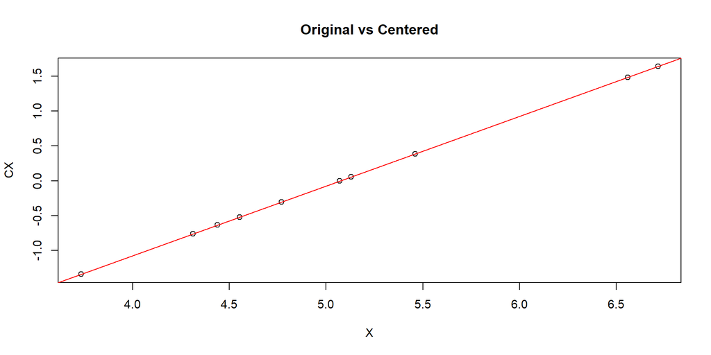

```r
plot(X, C%*%X, xlab="X", ylab="CX", main="Original vs Centered")
abline(a=-mean(X), b=1, col="red") # mean line
```

### Spectral decomposition of the centering matrix

```r
# Check the eigenvalues of C
eigen(C)$values
```

```
 [1] 1.000000e+00 1.000000e+00 1.000000e+00 1.000000e+00 1.000000e+00
 [6] 1.000000e+00 1.000000e+00 1.000000e+00 1.000000e+00 8.881784e-16
```

```r
# Check the eigenvectors of C
round(eigen(C)$vectors, 2)
```

```
       [,1]  [,2]  [,3]  [,4]  [,5]  [,6]  [,7]  [,8]  [,9] [,10]
 [1,]  0.00  0.00  0.00  0.00  0.00  0.95  0.00  0.00  0.00 -0.32
 [2,]  0.02  0.37  0.00 -0.09  0.24 -0.11 -0.04  0.83 -0.05 -0.32
 [3,]  0.00  0.79  0.00 -0.02  0.04 -0.11 -0.01 -0.51 -0.01 -0.32
 [4,]  0.87 -0.14  0.00 -0.15 -0.30 -0.11  0.10 -0.01  0.04 -0.32
 [5,] -0.25 -0.14  0.00  0.02 -0.25 -0.11  0.45 -0.01 -0.74 -0.32
 [6,] -0.25 -0.14  0.00 -0.04  0.03 -0.11  0.63 -0.01  0.64 -0.32
 [7,]  0.05 -0.35  0.00 -0.28  0.77 -0.11 -0.14 -0.24 -0.15 -0.32
 [8,]  0.05 -0.14  0.00  0.91  0.09 -0.11 -0.17 -0.01  0.04 -0.32
 [9,] -0.25 -0.14 -0.71 -0.18 -0.31 -0.11 -0.41 -0.01  0.11 -0.32
[10,] -0.25 -0.14  0.71 -0.18 -0.31 -0.11 -0.41 -0.01  0.11 -0.32
```

```r
Gamma=eigen(C)$vectors
# Check Gamma is orthogonal
Gamma%*%t(Gamma)
```

```
               [,1]          [,2]          [,3]          [,4]          [,5]
 [1,]  1.000000e+00 -2.775558e-17 -1.387779e-17 -1.387779e-17 -1.387779e-17
 [2,] -2.775558e-17  1.000000e+00  4.996004e-16 -9.714451e-17 -9.714451e-17
 [3,] -1.387779e-17  4.996004e-16  1.000000e+00 -1.665335e-16  1.387779e-17
 [4,] -1.387779e-17 -9.714451e-17 -1.665335e-16  1.000000e+00 -2.498002e-16
 [5,] -1.387779e-17 -9.714451e-17  1.387779e-17 -2.498002e-16  1.000000e+00
 [6,] -1.387779e-17 -9.714451e-17 -1.387779e-17 -1.249001e-16 -6.938894e-17
 [7,] -1.387779e-17  1.110223e-16 -2.775558e-17 -6.938894e-17 -2.775558e-17
 [8,] -1.387779e-17 -1.249001e-16  8.326673e-17  2.775558e-17  2.775558e-17
 [9,] -1.387779e-17 -1.110223e-16  4.163336e-17 -2.775558e-17  9.714451e-17
[10,] -1.387779e-17 -1.110223e-16  4.163336e-17 -2.775558e-17  2.081668e-16
               [,6]          [,7]          [,8]          [,9]         [,10]
 [1,] -1.387779e-17 -1.387779e-17 -1.387779e-17 -1.387779e-17 -1.387779e-17
 [2,] -9.714451e-17  1.110223e-16 -1.249001e-16 -1.110223e-16 -1.110223e-16
 [3,] -1.387779e-17 -2.775558e-17  8.326673e-17  4.163336e-17  4.163336e-17
 [4,] -1.249001e-16 -6.938894e-17  2.775558e-17 -2.775558e-17 -2.775558e-17
 [5,] -6.938894e-17 -2.775558e-17  2.775558e-17  9.714451e-17  2.081668e-16
 [6,]  1.000000e+00  1.804112e-16  1.387779e-17 -1.249001e-16 -1.387779e-17
 [7,]  1.804112e-16  1.000000e+00 -6.938894e-17 -6.938894e-17 -1.387779e-17
 [8,]  1.387779e-17 -6.938894e-17  1.000000e+00  1.110223e-16 -2.775558e-17
 [9,] -1.249001e-16 -6.938894e-17  1.110223e-16  1.000000e+00 -1.387779e-17
[10,] -1.387779e-17 -1.387779e-17 -2.775558e-17 -1.387779e-17  1.000000e+00
```

```r
t(Gamma)%*%Gamma
```

```
               [,1]          [,2]          [,3]          [,4]          [,5]
 [1,]  1.000000e+00 -1.249001e-16 -2.775558e-17 -5.551115e-17 -1.387779e-16
 [2,] -1.249001e-16  1.000000e+00 -1.387779e-17  5.551115e-17  8.326673e-17
 [3,] -2.775558e-17 -1.387779e-17  1.000000e+00 -1.110223e-16  5.551115e-17
 [4,] -5.551115e-17  5.551115e-17 -1.110223e-16  1.000000e+00 -9.714451e-17
 [5,] -1.387779e-16  8.326673e-17  5.551115e-17 -9.714451e-17  1.000000e+00
 [6,]  0.000000e+00  1.040834e-17  0.000000e+00 -6.938894e-18  2.775558e-17
 [7,] -2.775558e-17 -2.775558e-17  1.110223e-16 -2.775558e-17  2.220446e-16
 [8,]  7.546047e-17  2.949030e-17 -6.938894e-18 -2.602085e-18 -1.092876e-16
 [9,]  1.665335e-16 -2.081668e-17 -1.387779e-17  6.938894e-18  1.804112e-16
[10,]  5.551115e-17  1.387779e-16  2.775558e-17  0.000000e+00  5.551115e-17
               [,6]          [,7]          [,8]          [,9]         [,10]
 [1,]  0.000000e+00 -2.775558e-17  7.546047e-17  1.665335e-16  5.551115e-17
 [2,]  1.040834e-17 -2.775558e-17  2.949030e-17 -2.081668e-17  1.387779e-16
 [3,]  0.000000e+00  1.110223e-16 -6.938894e-18 -1.387779e-17  2.775558e-17
 [4,] -6.938894e-18 -2.775558e-17 -2.602085e-18  6.938894e-18  0.000000e+00
 [5,]  2.775558e-17  2.220446e-16 -1.092876e-16  1.804112e-16  5.551115e-17
 [6,]  1.000000e+00  2.775558e-17  8.630249e-17  6.938894e-18 -1.387779e-17
 [7,]  2.775558e-17  1.000000e+00  2.255141e-17  1.526557e-16  1.110223e-16
 [8,]  8.630249e-17  2.255141e-17  1.000000e+00 -6.938894e-18  2.931683e-16
 [9,]  6.938894e-18  1.526557e-16 -6.938894e-18  1.000000e+00  1.387779e-17
[10,] -1.387779e-17  1.110223e-16  2.931683e-16  1.387779e-17  1.000000e+00
```

Note that
$$\mathbb C=\sum_{i=j}^{n-1} \gamma_j\gamma_j^T$$

```r
Total_mat=matrix(0,10,10)
for(i in 1:9){
  Total_mat=Total_mat+Gamma[,i]%*%t(Gamma[,i])
}
all.equal(Total_mat, C)
```

```
[1] TRUE
```

### Center A Random Sample from Univariate

- The centering matrix centers data
- Univariate: Let $\mathbf X_{n\times 1}$ be a random sample from $N(\mu, \sigma^2)$, i.e.,
  $$\mathbf X_{n\times 1}\sim N(\mu\mathbf 1, \sigma^2 \mathbf I)$$

$\mathbb C\mathbf X$ is a linear function of $\mathbf X$ and it can be verified that $\mathbb C\mathbf 1=\mathbf 0$, we have
$$E[\mathbb C\mathbf X]=\mu \mathbb C\mathbf 1=\mathbf 0$$

### Center A Random Sample from Univariate

# Chi-squared distribution

## Definition

*Definition.* Let $Z_1, ..., Z_k \overset{iid}\sim N(0,1)$. Then, the sum of squares $Q = Z_1^2 + ... + Z_k^2$ has a chi-squared distribution with $k$ degrees of freedom, denoted by $\chi_k^2$.

- Alternatively, let $\mathbf Z_{k\times 1} \sim N(\mathbf 0, \mathbf I)$. We say $||\mathbf Z||^2=\mathbf Z^T \mathbf Z$ follows $\chi_k^2$.
- $Z_1^2, \cdots, Z_k^2 \overset{iid}\sim \chi_1^2$.
- The sum of independent chi-squared random variables is also chi-squared. Specifically, if $Q_1\sim \chi_{k_1}^2$ and $Q_2\sim \chi_{k_2}^2$ are independent, then $Q_1+Q_2\sim \chi_{k_1+k_2}^2$.

## Chi-squared vs Gamma

- The PDF of a chi-squared random variable with $k$ degrees of freedom is given by:

$$f(x) = \frac{1}{2^{k/2}\Gamma(k/2)} x^{k/2-1} e^{-x/2} \mbox{, } x>0$$

where $\Gamma(\cdot)$ is the gamma function.

- Remark: $\chi_k^2$ = Gamma(shape=$k/2$, rate=1/2).

### MGF and Moments

- The MGF of a chi-squared random variable with $k$ degrees of freedom is:
  $$M_X(t) = (1-2t)^{-k/2}$$
- The mean and variance of a chi-squared random variable with $k$ degrees of freedom are:

$$\text{E}[X] = k \mbox{, }\text{Var}[X] = 2k$$

## Construct Chi-squared R.V.s from Projection Matrices and Independent Normal R.V.s

- Let $\mathbf P_{n\times n}$ be a projection matrix with rank $r$ and let $\mathbf Z_{n\times 1}\sim N(\mathbf 0, \mathbf I)$.
- Claim: $\mathbf Z^T \mathbf P \mathbf Z\sim \chi_r^2$.
- Proof: By the spectral decomposition of $\mathbf P$, we have

$$P= \sum_{i=1}^r \gamma_i \gamma_i^T,$$
where $\gamma_1, \cdots, \gamma_r$ are orthogonal vectors of norm 1, i.e., $\gamma_i^T \gamma_j = 0$ for $i\not=j$ and $\gamma_i^T \gamma_i=1$ for $i=1, \cdots, r$.

$$\begin{aligned}
\mathbf Z^T \mathbf P \mathbf Z &= \mathbf Z^T \sum_{i=1}^r \gamma_i \gamma_i^T \mathbf Z= \sum_{i=1}^r \mathbf Z^T \gamma_i \gamma_i^T \mathbf Z\\
&= \sum_{i=1}^r (\gamma_i^T \mathbf Z)^T(\gamma_i^T \mathbf Z)
\end{aligned}$$

- Let $Y_i = \gamma_i^T \mathbf Z$.
- $Y_i$ is univariate and it is a linear combination of $\mathbf Z$, therefore it follows a normal distribution (univariate).

$$Y_i \sim N(\gamma_i^T \mathbf 0, \gamma_i^T \mathbf I \gamma_i^T)=N(0,1)$$

- $Cov(Y_i, Y_j)=cov(\gamma_i^T Z, \gamma_j^T)= \gamma_i^T\mathbf I \gamma_j^T=\gamma_i^T\mathbf \gamma_j^T=0$ for $i\not=j$. For MVN, zero covariance implies independence. Thus,

$$Y_1, \cdots, Y_r\overset{iid}\sim N(0,1).$$

- Consequently, $Y_i^2\overset{iid}\sim \chi_1^2$.
- Note that $\mathbf Z^T \mathbf P \mathbf Z=\sum_{i=1}^r Y_i^2$. By the definition of chi-squared distribution, we have
  $$\mathbf Z^T \mathbf P \mathbf Z\sim \chi_r^2.$$

## The Sample Variance

- Let $\mathbb C=\mathbf I - \frac{1}{n} \mathbf 1\mathbf 1^T$ be the centering matrix.
- We have shown that $\mathbb C$ is a projection matrix with rank $n-1$:
  - $\mathbb C^T=\mathbb C$, $\mathbb C^2=\mathbb C$.
  - $\mathbb C = \sum_{j=1}^{n-1}\gamma_i\gamma_i^T$.
- $(n-1)s^2=\mathbf X^T\mathbb C \mathbf X$ because

  $$\begin{aligned}
  (n-1)s^2&=\sum_{i=1}^n (X_i-\bar X)^2 = (\mathbb C \mathbf X)^T (\mathbb C \mathbf X) = \mathbf X^T \mathbb C \mathbf X.
  \end{aligned}$$
- $\mathbb C \mathbf X = \mathbb C (\mathbf X - E[\mathbf X])$ because
  - $E[\mathbf X] = \mu \mathbf 1$.
  - $\mathbb C \mathbf 1 = \mathbf 0$.
- Therefore,
  $$\begin{aligned}
  \frac{(n-1)s^2}{\sigma^2}&=\frac{\mathbf X^T \mathbb C \mathbf X}{\sigma^2}=\frac{\mathbf X^T \mathbb C^T \mathbb C \mathbb C \mathbf X}{\sigma^2}\\
  &=\frac{(\mathbb C\mathbf X)^T \mathbb C \mathbb C\mathbf X}{\sigma^2}\\
  &=\frac{(\mathbf X - E[\mathbf X])^T}{\sigma}\mathbb C \frac{(\mathbf X - E[\mathbf X])}{\sigma}
  \end{aligned}$$
- Let $\mathbf Z=\frac{(\mathbf X - E[\mathbf X])}{\sigma}$.
- Easy to see that $\mathbf Z\sim N(\mathbf 0, \mathbf I)$. Thus,

$$\frac{(n-1)s^2}{\sigma^2}=\mathbf Z^T \mathbb C \mathbf Z$$

- Use the result we derived, we have
  $$\frac{(n-1)s^2}{\sigma^2}=\mathbf Z^T \mathbb C \mathbf Z \sim \chi_{n-1}^2$$

# Sample Covariance

## The Sample Covriance from A MVN Random Sample

- Let $\mathbf X_1, \cdots,\mathbf X_n \overset{iid} \sim N(\boldsymbol \mu, \boldsymbol \Sigma)$.
- Recall that the sample covariance matrix is defined as
  $$\mathbf S =\frac{1}{n-1} \sum_{i=1}^n (\mathbf X_i - \bar{\mathbf X})(\mathbf X_i - \bar{\mathbf X})^T$$
- We have shown that
  $$(n-1)\mathbf S = \mathbf X ^T \mathbb C \mathbf X$$
  where $\mathbf X$ is the $n\times p$ random matrix.

## The Distribution of Sample Covriance

- The goal is to show that $(n-1)\mathbf S$ follows a Wishart distribution. More specifically, we would like to show that
  $$(n-1)\mathbf S \sim Wishart_p(n-1, \Sigma)$$
- Outline of proof
  1. Rewrite $(n-1)\mathbf S$
  2. Apply properties of a projection matrix
  3. Use the definition of Wishart distribution

## Wishart Distribution

- The Wishart distribution is named after the British statistician John Wishart, who introduced it in his 1928 paper published in Biometrika.
- Wishart was interested in the problem of estimating the covariance matrix of a multivariate normal distribution.
- Wishart showed that the sample covariance matrix follows a particular probability distribution that we now call the Wishart distribution.
- The Wishart distribution has become a fundamental tool in multivariate statistical analysis

## Definition

- A Wishart distribution can be defined in the following way
- Let $\mathbf W$ be a $p\times p$ random matrix.
- We say $\mathbf W$ follows $Wishart_{p}(k, \boldsymbol \Sigma)$ if $\mathbf W$ can be written as $\mathbf W=\mathbf X^T \mathbf X$ where $\mathbf X$ denotes the random matrix formed by a random sample of size $k$ from MVN $N(\mathbf 0, \boldsymbol \Sigma)$.
- Remark:$E[\mathbf W]=k\Sigma$.
- The definition indicates that if

$$\mathbf X_1, \cdots \mathbf X_k \overset{iid}\sim N(\mathbf 0, \boldsymbol \Sigma),$$

then
$$\mathbf X^T \mathbf X=\sum_{i=1}^k \mathbf X_i \mathbf X_i^T \sim Wishart_p(k, \boldsymbol \Sigma).$$

## Wishart vs Chi-squared

- *Wishart*: If $\mathbf X_1, \cdots \mathbf X_k \overset{iid}\sim N(\mathbf 0, \boldsymbol \Sigma)$, then
  $$\mathbf X^T \mathbf X =\sum_{i=1}^k \mathbf X_i\mathbf X_i^T \sim Wishart_p(k, \boldsymbol \Sigma) \mbox{, where } \mathbf X_{k\times p}=\begin{pmatrix}
  X_1^T\\ \vdots\\ X_k^T
  \end{pmatrix}$$
- *Chi-squared*: If $X_1, \cdots, X_k \overset{iid}\sim N(0,1)$, then
  $$\mathbf X^T\mathbf X=\sum_{i=1}^k X_i^2\sim \chi_k^2 \mbox{, where } \mathbf X_{k\times 1}=
  \begin{pmatrix}
  X_1 \\ \vdots \\ X_k
  \end{pmatrix}$$

### Wishart vs Chi-squared (continued)

- When $p=1$,
  $$W=\sum_{i=1}^k X_i^2 = \sigma^2 \sum_{i=1}^k \left(\frac{X_i}{\sigma} \right)^2\sim \sigma^2 \chi_k^2$$

## Sample Covariance

- The sample covariance $(n-1)\mathbf S=\mathbf X^T \mathbb C \mathbf X$.. The definition of Wishart distribution is not applicable immediately.
- Rewrite $(n-1)\mathbf S$:

$$\begin{aligned}
(n-1)\mathbf S&=\mathbf X^T \mathbb C^T\mathbb C\mathbb C \mathbf X=(\mathbb C \mathbf X)^T(\mathbb C \mathbf X)\\
&=(\mathbb C \mathbf X)^T\mathbb C(\mathbb C \mathbf X)\\
&=(\mathbb C \mathbf X)^T\sum_{j=1}^{n-1}\gamma_i \gamma_i^T (\mathbb C \mathbf X)\\
&=\sum_{j=1}^{n-1} (\gamma_i^T \mathbb C \mathbf X)^T (\gamma_i^T \mathbb C \mathbf X)
\end{aligned}$$

- Let $Y_i= (\gamma_i^T \mathbb C \mathbf X)^T=(\gamma_i^T \sum_j \gamma_j \gamma_j^T \mathbf X)^T = (\mathbf X)^T\gamma_i$, we have
  - $Y_i$ is a $p\times 1$ vector; it is a linear function of $\mathbf X$. Thus it follows a MVN.
  - $E[Y_i]=0$ because $\mathbb C$ is the centering matrix
  - The $j$th element of $Y_i$ is a linear function of the $j$ column of $\mathbf X$.
- In the following, we show that $Y_i$ and $Y_j$ are uncorrelated for $i\not=j$:

$$\begin{aligned}
Cov[Y_i, Y_j]&=E[(Y_i-\mathbf 0 )(Y_j-\mathbf 0)^T]\\
&= E[Y_iY_j^T] \\
&= E[(\gamma_i^T \mathbb C \mathbf X)^T(\gamma_j^T \mathbb C \mathbf X)]\\
&= E[\mathbf X^T \mathbb C \gamma_i \gamma_j^T \mathbb C \mathbf X] \\
&=\mathbf 0
\end{aligned}$$

The last step is true because for $i\not=j$, $\gamma_i \gamma_j^T=0$

- Since $Y_i$ and $Y_j$ are two linear combinations of the same MVN distributed random matrix (or its vectorized version), we have $Y_i$ and $Y_j$ are independent for $i\not=j$.
- We understand that $Y_i$ follows a MVN with mean $\mathbf 0$. How about its covariance matrix? Next, we introduce matrix normal distribution.

## Matrix Normal Distribution

- Let $\mathbf X_1, \cdots \mathbf X_n$ be a random sample (therefore iid) from $N(\boldsymbol \mu, \boldsymbol \Sigma)$.
- If we stack $\mathbf X_1, \cdots, \mathbf X_n$ into a $n\times p$ random matrix $\mathbf X$, we say follows a matrix normal distribution:
  $$\mathbf X \sim N(\mathbf 1_n \boldsymbol \mu^T, \boldsymbol \Sigma, \mathbf I_n)$$
- Consider the linear function $\mathbf X^T \mathbb a$. It can be shown that
  $$\mathbf X^T \mathbb a \sim N((\mathbf 1_n \boldsymbol \mu^T)^T \mathbb a, \mathbb a^T \mathbb a \boldsymbol \Sigma)\sim N(\boldsymbol \mu \mathbf 1_n \mathbb a, \mathbb a^T \mathbb a \boldsymbol \Sigma)$$
- Thus, $Y_i \sim N(\mathbf 0, \boldsymbol \Sigma)$.

### Wishart Distribution and Sample Covariance

- So far, we have the following:
  - $(n-1)\mathbf S=\sum_{j=1}^{n-1} Y_i Y_i^T$.
  - $Y_1, \cdots, Y_{n-1} \overset{iid} \sim N(\mathbf 0, \boldsymbol \Sigma)$ for $i=1, \cdots, n-1$.
- By the definition of Wishart, we can conclude that
  $$(n-1)\mathbf S\sim Wishart_p(n-1, \boldsymbol \Sigma)$$

## Some Interesting Results

- Consider a random sample from MVN $N(\boldsymbol \mu, \boldsymbol \Sigma)$. Let $\mathbf S$ denote the sample covariance matrix.
- We have already shown that $(n-1)\mathbf S \sim Wishart_p(n-1, \boldsymbol \Sigma)$
- What is the distribution of a diagonal element of $(n-1)\mathbf S$?
- What is the distribution of the sum of elements of $(n-1)\mathbf S$? Note, this is a special case of next question with $\mathbf B=(1, \cdots, 1)$.
- What is the distribution of $(n-1)\mathbf B \mathbf S \mathbf B^T$ where $B$ is a fixed $q\times p$ matrix?
- If time permits, we will run some simulations
- If you cannot get the answer to the last question, let’s use the definition of Wishart distribution.
- Let $\mathbf W = (n-1)S$. Because it follows $Wishart_p(n-1, \boldsymbol\Sigma)$, we know that $\mathbf W=\sum_{j=1}^{n-1} \mathbf Z_j \mathbf Z_j^T$ where $\mathbf Z_j$’s are iid frm $N(\mathbf 0, \boldsymbol\Sigma)$.
- Then
  $$\begin{aligned}
  (n-1)\mathbf B \mathbf S \mathbf B^T &= \mathbf B\sum_{j=1}^{n-1} \mathbf Z_j \mathbf Z_j^T\mathbf B = \sum_{j=1}^{n-1} \mathbf B \mathbf Z_j \mathbf Z_j^T\mathbf B^T\\
  &= \sum_{j=1}^{n-1} (\mathbf B \mathbf Z_j)(\mathbf B \mathbf Z_j)^T
  \end{aligned}$$

Let $\mathbf Y_j=\mathbf B \mathbf Z_j$. Note that it is a linear function of $\mathbf Z_j$; therefore
$$\mathbf Y_j\sim N(\mathbf 0, \mathbf B \boldsymbol \Sigma \mathbf B^T)$$
and the $\mathbf Y_j$’s are iid (becaue …).

By the definition of Wishart distribution, we have

$$(n-1)\mathbf B \mathbf S \mathbf B^T\sim Wishart_q(n-1, \mathbf B \boldsymbol \Sigma \mathbf B^T)$$